# Data visualization: ggplot layers

# 1 Learning objectives

1. You can explain how the layers of the Grammar of Graphics translate to `ggplot2` code.
2. You can identify which `ggplot2` functions and arguments relate to the various elements of the grammar.
3. You can use the `+` sign to chain together `ggplot2` functions to build a layered plot.

https://medium.com/tdebeus/think-about-the-grammar-of-graphics-when-improving-your-graphs-18e3744d8d18

# 2 Introduction

In the previous lesson, we learned that the package `ggplot2` is based on the grammar of graphics (GG), which is a framework for data visualization that dissects each feature of a graph into individual components, creating distinct *layers.*

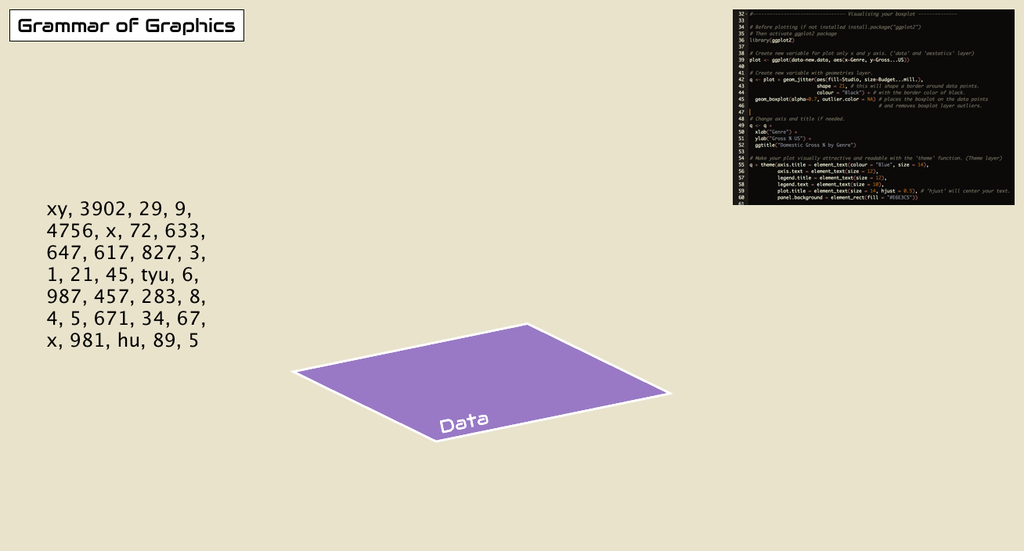

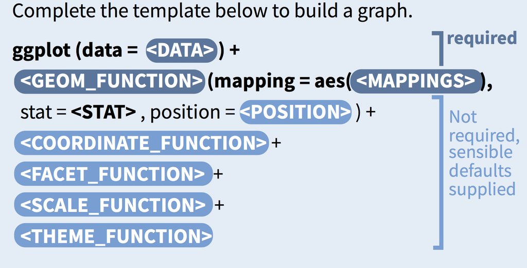

Let us build a complex graph with `ggplot2` that has all seven GG elements. We’ll do this by starting with a simple graph and adding additional layers, one at a time.

`ggplot2` code is easier to read if each line represents a new element. This style is generally favored for `ggplot2` code in the `R` community. This means that as you add each layer, you should start a new line. As we add more and more layers to plots, you’ll see this will greatly improve the legibility of your code.

# 3 The Mali childhood diarrheal disease dataset

In this lesson, we will use `ggplo2` to visualize data from from a prospective observational study of recording acute diarrhea in children 0-59 months in conducted in Mali in early 2020. The full dataset can be obtained from [Dryad](https://doi.org/10.5061/dryad.0rxwdbs19), and the paper can be viewed [here](https://elifesciences.org/articles/72294).

A prospective study watches for outcomes, such as the development of a disease, during the study period and relates this to other factors such as suspected risk or protection factors.

Spend some time browsing through this dataset. Each row corresponds to one patient surveyed. There are demographic, physiological, clinical, socioeconomic, and geographic variables.

```r
malidd <- read.csv(here::here("ch03_intro_to_data_viz/data/clean/malidd.csv"))
malidd
```

| n | admit_date | sex | age_months | height_cm | muac_cm | breastfeeding | vomit | fever | bloody_stool | temp | freqrespi | viral_load | diarrhea_days | diarrhea_episodes | medication | traditional_medication | commune | mother_education | father_education | household_size |
| --- | --- | --- | --- | --- | --- | --- | --- | --- | --- | --- | --- | --- | --- | --- | --- | --- | --- | --- | --- | --- |
| 1 | 2020-01-16 | M | 5 | 61.2 | 11.3 | 1 | 0 | 0 | 0 | 35.3 | 42 | 0.5727 | 3 | 6 | 0 | 1 | Golobougou | 0 | 0 | 30 |
| 2 | 2020-01-17 | F | 12 | 70.6 | 13.2 | 1 | 1 | 1 | 0 | 36.7 | 32 | 0.7362 | 4 | 5 | 1 | 1 | Kalaban-Coura | 13 | 0 | 6 |
| 3 | 2020-01-17 | M | 11 | 71.1 | 13.5 | 1 | 1 | 0 | 0 | 35.8 | 60 | 0.5536 | 2 | 3 | 0 | 0 | Kalabancoura | 13 | 16 | 22 |
| 4 | 2020-01-17 | M | 9 | 68.5 | 12.6 | 1 | 0 | 0 | 0 | 35.8 | 50 | 0.5536 | 3 | 5 | 0 | 1 | Quartier-Mali | 0 | 0 | 20 |
| 5 | 2020-01-21 | F | 16 | 78.7 | 14.2 | 1 | 1 | 0 | 0 | 36.4 | 42 | 0.7304 | 0 | 3 | 0 | 0 | Kabala | 13 | 17 | 8 |
| 6 | 2020-01-21 | M | 6 | 67.7 | 14.5 | 1 | 0 | 0 | 0 | 35.7 | 52 | 0.666 | 0 | 5 | 0 | 0 | Kalabancoura | 13 | 15 | 3 |
| 7 | 2020-01-22 | M | 5 | 64.7 | 14.1 | 1 | 0 | 0 | 0 | 35.7 | 58 | 0.6681 | 2 | 4 | 0 | 0 | Baco-Djicoroni | 0 | 6 | 6 |
| 8 | 2020-01-22 | M | 46 | 98.1 | 14.4 | 0 | 1 | 0 | 0 | 36 | 32 | 0.2337 | 3 | 4 | 0 | 0 | Niamakoro-Courani | 0 | 14 | 10 |
| 9 | 2020-01-17 | M | 4 | 61.2 | 13.1 | 1 | 0 | 1 | 0 | 35.3 | 49 | 0.6529 | 2 | 7 | 1 | 0 | Sabalibougou | 12 | 16 | 3 |
| 10 | 2020-01-21 | M | 25 | 85.7 | 15 | 0 | 1 | 1 | 0 | 36 | 26 | 0.4094 | 7 | 3 | 0 | 0 | Tiebani | 3 | 5 | 4 |

[output cut: 140 more lines]

We will be visualizing the relationship between the two numerical variables using a scatterplot:

1. `age_months`: child **age** in months on the horizontal *x* axis and
2. `height_cm`: child **height** in centimeters on the vertical *y* axis

# 4 Working through the layers

Let us build a complex graph with `ggplot2` that has all seven GG elements. We’ll do this by starting with a simple graph and adding additional layers, one at a time.

`ggplot2` code is easier to read if each line represents a new element. This style is generally favored for `ggplot2` code in the `R` community. This means that as you add each layer, you should start a new line. As we add more and more layers to plots, you’ll see this will greatly improve the legibility of your code.

## 4.1 Data layer

The first function in building a graph is the `ggplot` function. It specifies the the data frame containing the data to be mapped to visual properties of the graph.

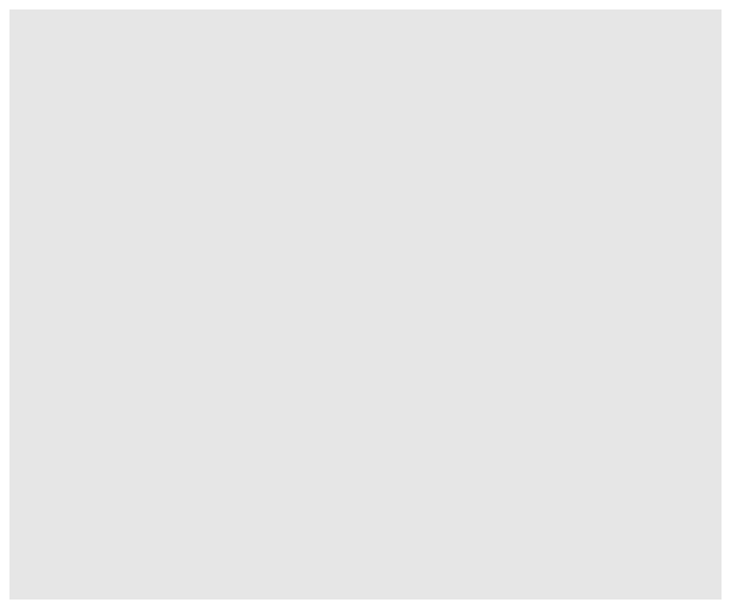

```r
# Layer 1: Data
ggplot(data = malidd)
```

However, without any other information, our data will not be visualized. We need to tell the function which specific variables in the data frame we want to map. The mappings are placed within the `aes` function (where `aes` stands for aesthetics).

## 4.2 Aesthetics layer

In `ggplot2`, aesthetics are a group of parameters that specify what and how data is displayed. Here, we are telling `R` to plot `age_months` on the `x` axis and `height_cm` on the `y` axis.

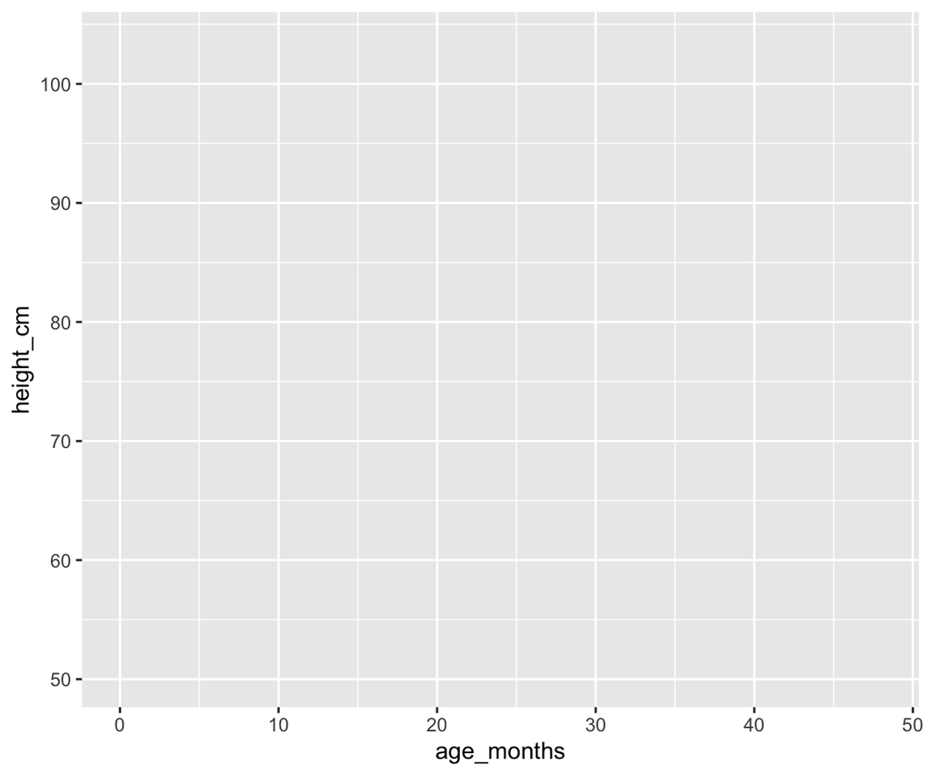

```r
# Next layer: aesthetics.
# Here, we tell R to plot age on the x axis, and height on the y axis but we still haven't told R how we want these data to be represented...
ggplot(data = malidd,
       aes(x = age_months,
           y = height_cm))
```

```r
# See? Our variables are now assigned to the x and y axes, but nothing is plotted yet.
```

Why is the graph still empty? We specified that the `age_months` variable should be mapped to the x-axis and that `height_cm` should be mapped to the y-axis, but we haven’t yet told `R` *how* we want to represent the data though, so our data will not yet be plotted. To do this, we need to specify at least one geometric object to determine the visual representation of our data.

## 4.3 Geometric layer

Geometric objects, or `geoms`, are the actual visual elements used for the data in the plot (points, lines, bars, etc.) that can be placed on a graph. They are added using functions that start with `geom_`. In this example, we’ll add points using the `geom_point` function, creating a scatterplot, to see how age and height relate to each other.

In `ggplot2` graphs, functions are chained together using the `+` sign to build a final plot.

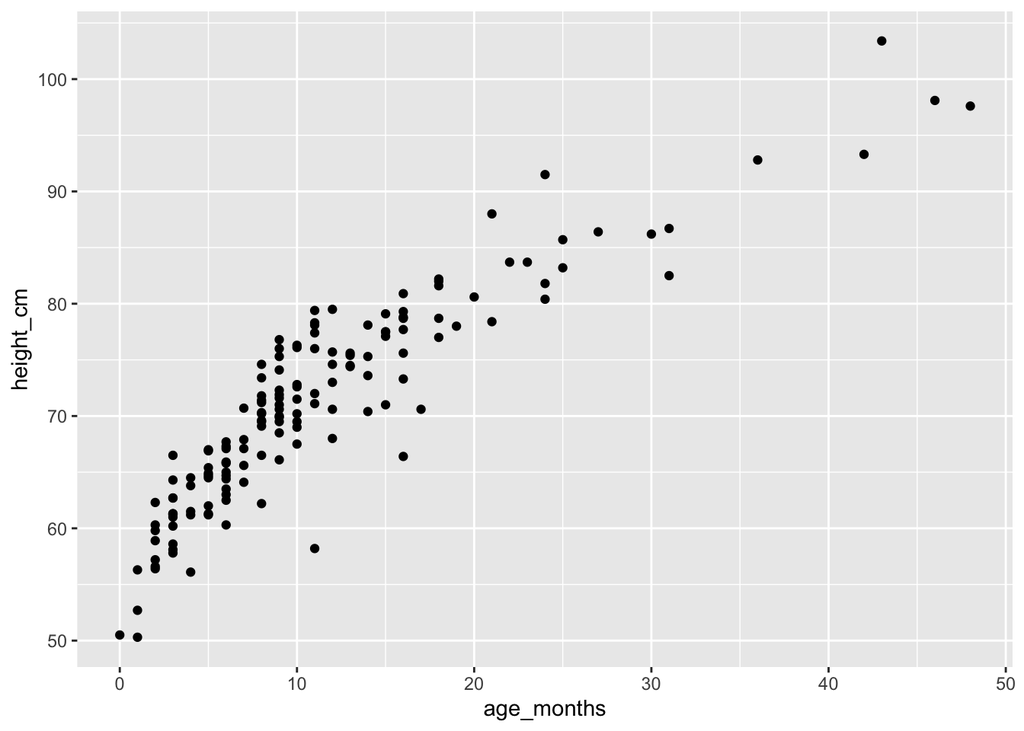

```r
# Next layer(s): geometric object(s)
ggplot(data = malidd,
       aes(x = age_months,
           y = height_cm)) + # Use the plus sign to add each additional layer
  geom_point() # The geom layer determines what style of plot we are using.
```

```r
               # geom_point() plots the data as points!
```

Note that the `+` sign comes at the end of lines, and not at the beginning. You’ll get an error in R if you put it at the beginning of a line. When adding layers to a plot, you are encouraged to start a new line after the `+` so that the code for each layer is on a new line.

A number of parameters (options) can be specified in a `geom_` function. Options for the `geom_point` function include `color`, `size`, and `alpha`. These control the point color, size, and transparency, respectively. Transparency ranges from 0 (completely transparent) to 1 (completely opaque). Adding a degree of transparency can help visualize overlapping points. You can also add several `geoms` to one plot. But for now, let us keep it simple!

## 4.4 Statistics layer

Next, let’s add line of best fit. We can do this by adding a statistical layer with the `stat_smooth` function.

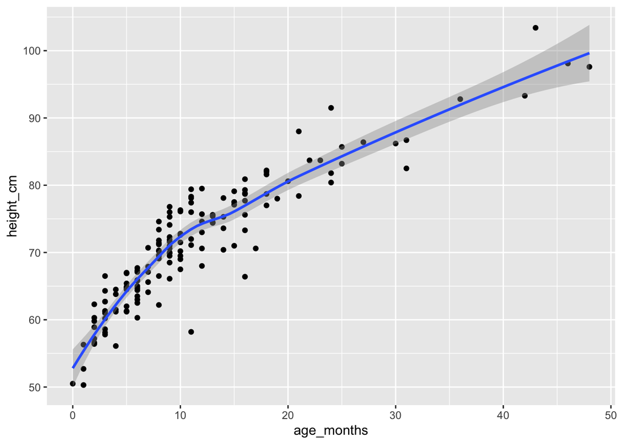

```r
# Add a line of best fit
ggplot(data = malidd,
       mapping = aes(x = age_months, y = height_cm)) +
  geom_point() +
  stat_smooth()
```

This tells us that height appears to increase with age.

## 4.5 Facets, coordinates, and themes

Now that the dataset is plotted, we can customize the plot to clarify the message, or to add more information. Facets are a popular way of dividing a plot into several windows according to some discrete category in the data, to visually differentiate groupings.

We can explore this plot differently if we use the `facet_wrap()` funtion to create two separate “facets” according to sex:

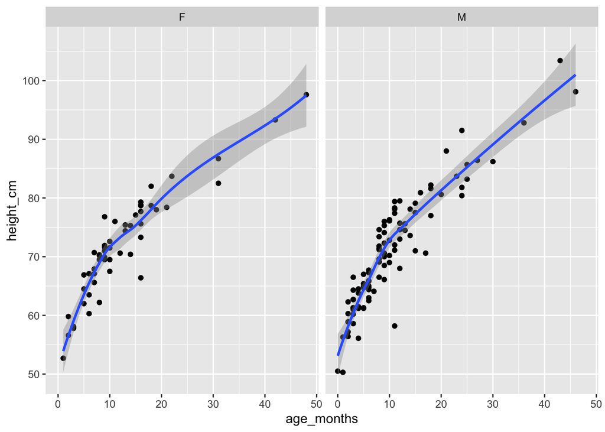

```r
# Next layer(s): customizations!
# Facets split a plot into separate windows according to some category in the data.
ggplot(data = malidd,
       aes(x = age_months,
           y = height_cm)) +
  geom_point() +
  geom_smooth() +
  facet_wrap(vars(sex)) # This splits the plot into two windows: one for each sex.
```

You could also use `facet_grid()` if you wanted to facet according to two variables.

We can also adjust the scale of our axes in the plot itself, rather than transforming the data. Let us assume we are interested in looking at the height measurements on a $log_{10}$ scale.

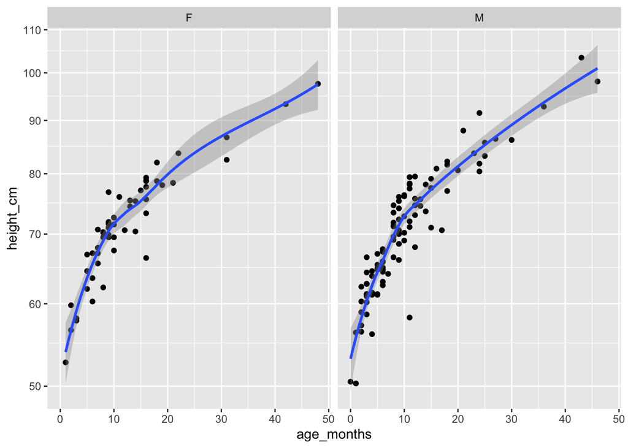

```r
ggplot(data = malidd,
       aes(x = age_months,
           y = height_cm)) +
  geom_point() +
  geom_smooth() +
  facet_wrap(vars(sex)) +
  # this transforms the axes' coordinates using log10()
  coord_trans(y = "log10")
```

As a final touch, we can also customize the plot’s theme, which includes its background, grid lines, and other visual characteristics of the plot. Let us assume we do not like the default grey background from `ggplot2` (we would not be alone in this!). We can use `theme_bw()` to produce a more visually appealing plot.

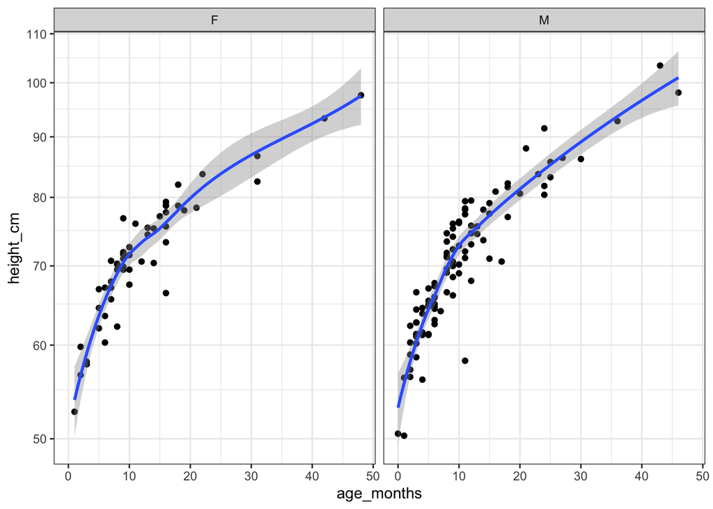

```r
ggplot(data = malidd,
       aes(x = age_months,
           y = height_cm)) +
  geom_point() +
  geom_smooth() +
  facet_wrap(vars(sex)) +
  coord_trans(y = "log10") +
  # this uses a nicer theme for our final plot
  theme_bw()
```

# Contributors

The following team members contributed to this lesson:

- [JOY VAZ](https://thegraphcourses.org/members/joy)  
  R Developer and Instructor, The Graph Network

  Loves doing science and teaching sciene.

# References

Some material in this lesson was adapted from the following sources:

- Kabacoff, Rob. 2020. *Data Visualization with R*. https://rkabacoff.github.io/datavis/.
- Giroux-Bougard, Xavier, Maxwell Farrell, Amanda Winegardner, Étienne Low-Decarie and Monica Granados. 2020. *Workshop 3: Introduction to Data Visualisation with Ggplot2*. http://r.qcbs.ca/workshop03/book-en/.

This work is licensed under the [Creative Commons Attribution Share Alike](https://creativecommons.org/licenses/by-sa/4.0/) license.